# Refamiliarize with Silge

John Little

2021-04-07

Abstract

SA = algorithmically mapping the emotion or opinion of a text.

Find this repository: https://github.com/libjohn/workshop_textmining

Much of this review comes from the site: https://juliasilge.github.io/tidytext/

The primary library package `tidytext` enables all kinds of text mining. See Also this helpful free online book: [Text Mining with R: A Tidy Approach](https://www.tidytextmining.com/) by Silge and Robinson

```r
library(janeaustenr)
library(tidyverse)
library(tidytext)
library(wordcloud2)
```

## Data

```r
austen_books()
```

|  | text | book |
| --- | --- | --- |
| 1 | SENSE AND SENSIBILITY | Sense & Sensibility |
| 2 |  | Sense & Sensibility |
| 3 | by Jane Austen | Sense & Sensibility |
| 4 |  | Sense & Sensibility |
| 5 | (1811) | Sense & Sensibility |
| 6 |  | Sense & Sensibility |
| 7 |  | Sense & Sensibility |
| 8 |  | Sense & Sensibility |
| 9 |  | Sense & Sensibility |
| 10 | CHAPTER 1 | Sense & Sensibility |

[output cut: 990 more lines]

Austen is best know for six published works:

```r
austen_books() %>%
  distinct(book)
```

| book |
| --- |
| Sense & Sensibility |
| Pride & Prejudice |
| Mansfield Park |
| Emma |
| Northanger Abbey |
| Persuasion |

## Data Cleaning

Text mining typically requires a lot of data cleaning. In this case, we start with the `janeaustenr` collection that has already been cleaned. Nonetheless, further data wrangling is required. First, identifying a line number for each line of text in each book.

## Identify line numbers

```r
original_books <- austen_books() %>%
  group_by(book) %>%
  mutate(line = row_number()) %>%         # identify line numbers
  ungroup()

original_books
```

| text | book | line |
| --- | --- | --- |
| SENSE AND SENSIBILITY | Sense & Sensibility | 1 |
|  | Sense & Sensibility | 2 |
| by Jane Austen | Sense & Sensibility | 3 |
|  | Sense & Sensibility | 4 |
| (1811) | Sense & Sensibility | 5 |
|  | Sense & Sensibility | 6 |
|  | Sense & Sensibility | 7 |
|  | Sense & Sensibility | 8 |
|  | Sense & Sensibility | 9 |
| CHAPTER 1 | Sense & Sensibility | 10 |

[output cut: 990 more lines]

## Tokens

To work with these data as a **tidy** dataset, we need to restructure the data through *tokenization*. In our case a token is a single word. We want **one-token-per-row**. The `unnest_tokens()` function (tidytext package) will convert a data frame with a text column into the one-token-per-row format.

**Token**  
**Tokenization**  
[defined](https://www.techopedia.com/definition/13698/tokenization)

The default tokenizing mode is “words”. With the `unnest_tokens()` function, tokens can be: **words**, characters, character_shingles, **ngrams**, skip_ngrams, **sentences**, lines, paragraphs, regex, tweets, and ptb (Penn Treebank).

### Process

1. Group by **line number** (above)
2. Make each single word a token

```r
tidy_books <- original_books %>%
  unnest_tokens(word, text)

tidy_books
```

| book | line | word |
| --- | --- | --- |
| Sense & Sensibility | 1 | sense |
| Sense & Sensibility | 1 | and |
| Sense & Sensibility | 1 | sensibility |
| Sense & Sensibility | 3 | by |
| Sense & Sensibility | 3 | jane |
| Sense & Sensibility | 3 | austen |
| Sense & Sensibility | 5 | 1811 |
| Sense & Sensibility | 10 | chapter |
| Sense & Sensibility | 10 | 1 |
| Sense & Sensibility | 13 | the |

[output cut: 990 more lines]

> Now that the data is in the one-word-per-row format, we can manipulate it with tidy tools like dplyr.

## Stop Words

`tidytext::get_stopwords()`

Remove stop-words from the books.

```r
matchwords_books <- tidy_books %>%
  anti_join(get_stopwords())
matchwords_books
```

| book | line | word |
| --- | --- | --- |
| Sense & Sensibility | 1 | sense |
| Sense & Sensibility | 1 | sensibility |
| Sense & Sensibility | 3 | jane |
| Sense & Sensibility | 3 | austen |
| Sense & Sensibility | 5 | 1811 |
| Sense & Sensibility | 10 | chapter |
| Sense & Sensibility | 10 | 1 |
| Sense & Sensibility | 13 | family |
| Sense & Sensibility | 13 | dashwood |
| Sense & Sensibility | 13 | long |

[output cut: 990 more lines]

### Join types

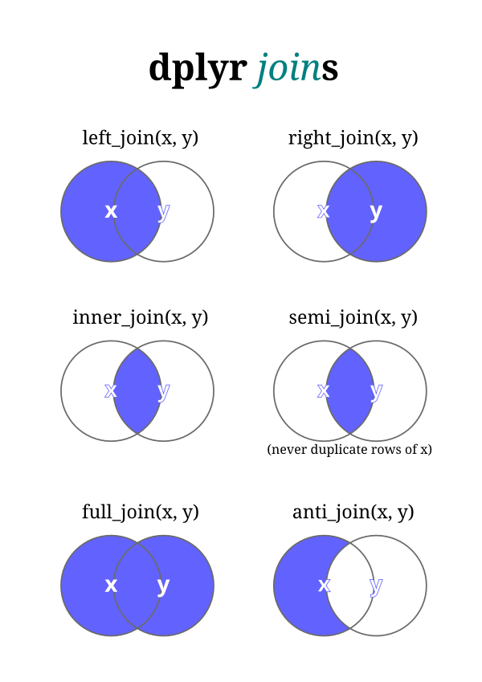

### Customize your dictionaries

You can customize stop-words data frames, sentiment data frames, etc.

There are various *stop words* dictionaries. Here we add the stop word, “farfegnugen” to a custom dictionary. If Jane Austen ever used the word “farfegnugen” that would be weird, or bad. So we will take pains to not calculate the sentiment of that word - whether or not the term shows up in a sentiment dictionary. That is, we will remove the word by making it a part of a customized stop-words dictionary.

```r
stopwords::stopwords_getsources()
```

```
[1] "snowball"      "stopwords-iso" "misc"          "smart"         "marimo"        "ancient"       "nltk"
[8] "perseus"
```

```r
stopwords::stopwords_getlanguages("snowball")
```

```
 [1] "da" "de" "en" "es" "fi" "fr" "hu" "ir" "it" "nl" "no" "pt" "ro" "ru" "sv"
```

```r
stopwords_custom <- tribble(~word, ~lexicon,
                            "farfegnugen", "custom")

stopwords_custom
```

| word | lexicon |
| --- | --- |
| farfegnugen | custom |

```r
get_stopwords(source = "snowball")
```

| word | lexicon |
| --- | --- |
| i | snowball |
| me | snowball |
| my | snowball |
| myself | snowball |
| we | snowball |
| our | snowball |
| ours | snowball |
| ourselves | snowball |
| you | snowball |
| your | snowball |

[output cut: 165 more lines]

```r
bind_rows(get_stopwords(), stopwords_custom)    # The default is "snowball"
```

| word | lexicon |
| --- | --- |
| i | snowball |
| me | snowball |
| my | snowball |
| myself | snowball |
| we | snowball |
| our | snowball |
| ours | snowball |
| ourselves | snowball |
| you | snowball |
| your | snowball |

[output cut: 166 more lines]

```r
NA
```

### Calculate word frequency

How many Austen countable words are there if we remove *snowball* stop-words? There are 14375 countable words.

```r
matchwords_books %>%
  # distinct(word)
  count(word, sort = TRUE)
```

| word | n |
| --- | --- |
| mr | 3015 |
| mrs | 2446 |
| must | 2071 |
| said | 2041 |
| much | 1935 |
| miss | 1855 |
| one | 1831 |
| well | 1523 |
| every | 1456 |
| think | 1440 |

[output cut: 990 more lines]

## Word clouds

```r
matchwords_books %>%
  count(word, sort = TRUE) %>%
  head(100) %>%
  wordcloud2(size = .4, shape = 'triangle-forward',
             color = c("steelblue", "firebrick", "darkorchid"),
             backgroundColor = "salmon")
```

[interactive chart not shown]

```r
NA
```

### Basic word cloud

A non-interactive word cloud.

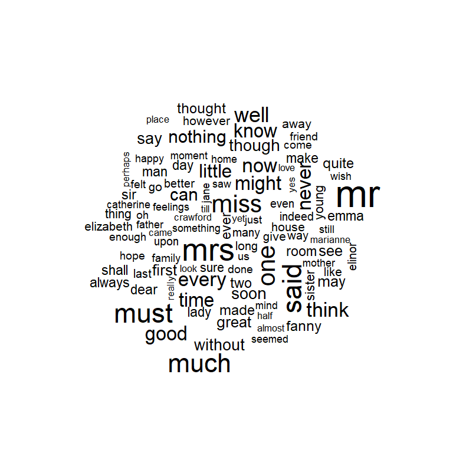

```r
matchwords_books %>%
  count(word) %>%
  with(wordcloud::wordcloud(word, n, max.words = 100))
```

## Your Turn: Exercise 1

Goal: Make a basic word cloud for the novel, *Pride and Predjudice*, `pride_prej_novel`

1. Prepare

```r
pride_prej_novel <- tibble(text = prideprejudice) %>%
  mutate(line = row_number())
```

2. Tokenize `pride_prej_novel` with `unnest_tokens()`
3. Remove stop-words
4. calculate word frequency
5. make a simple wordcloud

## Sentiment Analysis

`get_sentiments()`

Let’s see what positive words exist in the bing dictionary. Then, count the frequency of those positive words that exist in *Emma*.

```r
positive <- get_sentiments("bing") %>%
  filter(sentiment == "positive")                    # get POSITIVE words

positive
```

| word | sentiment |
| --- | --- |
| abound | positive |
| abounds | positive |
| abundance | positive |
| abundant | positive |
| accessable | positive |
| accessible | positive |
| acclaim | positive |
| acclaimed | positive |
| acclamation | positive |
| accolade | positive |

[output cut: 990 more lines]

```r
tidy_books %>%
  filter(book == "Emma") %>%                        # only the book _emma_
  semi_join(positive) %>%                           # semi_join()
  count(word, sort = TRUE)
```

| word | n |
| --- | --- |
| well | 401 |
| good | 359 |
| great | 264 |
| like | 200 |
| better | 173 |
| enough | 129 |
| happy | 125 |
| love | 117 |
| pleasure | 115 |
| right | 92 |

[output cut: 658 more lines]

### Prepare to visualize sentiment score

Match all the Austen books to the bing sentiment dictionary. Count the word frequency.

```r
tidy_books %>%
  inner_join(get_sentiments("bing")) %>%
  count(book)
```

| book | n |
| --- | --- |
| Sense & Sensibility | 8604 |
| Pride & Prejudice | 8704 |
| Mansfield Park | 11577 |
| Emma | 11966 |
| Northanger Abbey | 5762 |
| Persuasion | 5674 |

### Calculate sentiment

> **Algorithm:** sentiment = positive - negative

Define a section of text.

> "Small sections of text may not have enough words in them to get a good estimate of sentiment while really large sections can wash out narrative structure. For these books, using 80 lines works well, but this can vary depending on individual texts… – [Text Mining with R](https://www.tidytextmining.com/sentiment.html)

```r
bing <- get_sentiments("bing")

janeaustensentiment <- tidy_books %>%
  inner_join(bing) %>%
  count(book, index = line %/% 80, sentiment) %>%                          # `%/%` = int division ; 80 lines / section
  pivot_wider(names_from = sentiment, values_from = n, values_fill = 0) %>%    # spread(sentiment, n, fill = 0)
  mutate(sentiment = positive - negative)                                      # ALGO!!!
janeaustensentiment
```

| book | index | negative | positive | sentiment |
| --- | --- | --- | --- | --- |
| Sense & Sensibility | 0 | 16 | 32 | 16 |
| Sense & Sensibility | 1 | 19 | 53 | 34 |
| Sense & Sensibility | 2 | 12 | 31 | 19 |
| Sense & Sensibility | 3 | 15 | 31 | 16 |
| Sense & Sensibility | 4 | 16 | 34 | 18 |
| Sense & Sensibility | 5 | 16 | 51 | 35 |
| Sense & Sensibility | 6 | 24 | 40 | 16 |
| Sense & Sensibility | 7 | 23 | 51 | 28 |
| Sense & Sensibility | 8 | 30 | 40 | 10 |
| Sense & Sensibility | 9 | 15 | 19 | 4 |

[output cut: 910 more lines]

### Viz it

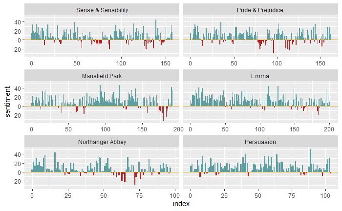

```r
janeaustensentiment %>%
  ggplot(aes(index, sentiment, )) +
  geom_col(show.legend = FALSE, fill = "cadetblue") +
  geom_col(data = . %>% filter(sentiment < 0), show.legend = FALSE, fill = "firebrick") +
  geom_hline(yintercept = 0, color = "goldenrod") +
  facet_wrap(~ book, ncol = 2, scales = "free_x")
```

### Preparation: Most common positive and negative words

```r
bing_word_counts <- tidy_books %>%
  inner_join(bing) %>%
  count(word, sentiment, sort = TRUE)
bing_word_counts
```

| word | sentiment | n |
| --- | --- | --- |
| miss | negative | 1855 |
| well | positive | 1523 |
| good | positive | 1380 |
| great | positive | 981 |
| like | positive | 725 |
| better | positive | 639 |
| enough | positive | 613 |
| happy | positive | 534 |
| love | positive | 495 |
| pleasure | positive | 462 |

[output cut: 990 more lines]

### Viz it too

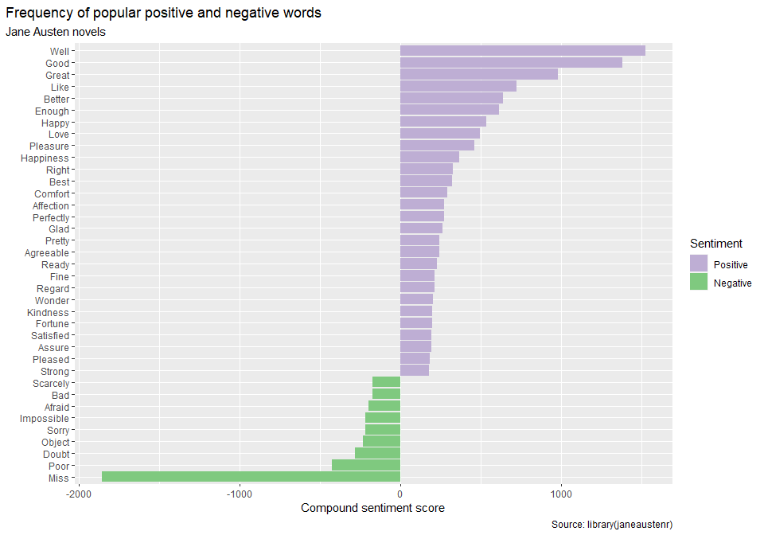

```r
bing_word_counts %>%
  filter(n > 170) %>%
  mutate(n = if_else(sentiment == "negative", - n, n)) %>%
  ggplot(aes(fct_reorder(str_to_title(word), n), n, fill = str_to_title(sentiment))) +
  geom_col() +
  coord_flip() +
  scale_fill_brewer(type = "qual") +
  guides(fill = guide_legend(reverse = TRUE)) +
  labs(title = "Frequency of popular positive and negative words",
       subtitle = "Jane Austen novels",
       y = "Compound sentiment score", x = "",
       fill = "Sentiment", caption = "Source: library(janeaustenr)") +
  theme(plot.title.position = "plot")
```

## Dictionaries

What other dictionaries are available? How to choose?

- [Without Dictiionaries there is no sentiment analysis](http://www.thinkingondata.com/without-dictionaries-no-sentiment-analysis/)
- [Sentiment Analysis: Analyzing Lexicon Quality and Estimation Errors](https://paulvanderlaken.com/2017/12/27/sentiment-analysis-lexicon-quality/)
- [Limits of the Bing, AFINN, and NRC Lexicons with the Tidytext Package in R](https://hoyeolkim.wordpress.com/2018/02/25/the-limits-of-the-bing-afinn-and-nrc-lexicons-with-the-tidytext-package-in-r/)
- [Case Study with Harry Potter](https://afit-r.github.io/sentiment_analysis)

```r
head(get_sentiments("bing"))
```

| word | sentiment |
| --- | --- |
| 2-faces | negative |
| abnormal | negative |
| abolish | negative |
| abominable | negative |
| abominably | negative |
| abominate | negative |

```r
head(get_sentiments("loughran"))
```

| word | sentiment |
| --- | --- |
| abandon | negative |
| abandoned | negative |
| abandoning | negative |
| abandonment | negative |
| abandonments | negative |
| abandons | negative |

```r
head(get_sentiments("nrc"))
```

| word | sentiment |
| --- | --- |
| abacus | trust |
| abandon | fear |
| abandon | negative |
| abandon | sadness |
| abandoned | anger |
| abandoned | fear |

```r
head(get_sentiments("afinn"))
```

| word | value |
| --- | --- |
| abandon | -2 |
| abandoned | -2 |
| abandons | -2 |
| abducted | -2 |
| abduction | -2 |
| abductions | -2 |

```r
get_sentiments("nrc") %>%
  count(sentiment, sort = TRUE)
```

| sentiment | n |
| --- | --- |
| negative | 3324 |
| positive | 2312 |
| fear | 1476 |
| anger | 1247 |
| trust | 1231 |
| sadness | 1191 |
| disgust | 1058 |
| anticipation | 839 |
| joy | 689 |
| surprise | 534 |

```r
NA
```

## Afinn

What words in *Emma* match the AFINN dictionary?

```r
emma_afinn <- tidy_books %>%
  filter(book == "Emma") %>%
  anti_join(get_stopwords()) %>%
  inner_join(get_sentiments("afinn"))
emma_afinn
```

| book | line | word | value |
| --- | --- | --- | --- |
| Emma | 15 | clever | 2 |
| Emma | 15 | rich | 2 |
| Emma | 15 | comfortable | 2 |
| Emma | 16 | happy | 3 |
| Emma | 16 | best | 3 |
| Emma | 18 | distress | -2 |
| Emma | 20 | affectionate | 3 |
| Emma | 22 | died | -3 |
| Emma | 24 | excellent | 3 |
| Emma | 25 | fallen | -2 |

[output cut: 990 more lines]

```r
emma_afinn %>%
  count(word, sort = TRUE)
```

| word | n |
| --- | --- |
| miss | 599 |
| good | 359 |
| great | 264 |
| dear | 241 |
| like | 200 |
| better | 173 |
| hope | 143 |
| poor | 136 |
| wish | 135 |
| happy | 125 |

[output cut: 884 more lines]

### Make Sections

Just as we calculated sentiment, above, make sections of 80 words then calculate sentiment.

```r
emma_afinn_sentiment <- emma_afinn %>%
  mutate(word_count = 1:n(),
         index = word_count %/% 80) %>%
  group_by(index) %>%
  summarise(sentiment = sum(value))           ## ALGO sum each Afinn score in the 80 word section
emma_afinn_sentiment
```

| index | sentiment |
| --- | --- |
| 0 | 40 |
| 1 | 33 |
| 2 | 77 |
| 3 | 84 |
| 4 | 52 |
| 5 | 80 |
| 6 | 98 |
| 7 | 80 |
| 8 | 69 |
| 9 | 68 |

[output cut: 117 more lines]

```r
NA
```

### Viz it

```r
emma_afinn %>%
  mutate(word_count = 1:n(),
         index = word_count %/% 80) %>%
  filter(index == 104) %>%
  count(word, sort = TRUE) %>%
  wordcloud2(size = .4, shape = 'diamond',
             backgroundColor = "darkseagreen")
```

[interactive chart not shown]

```r
NA
```

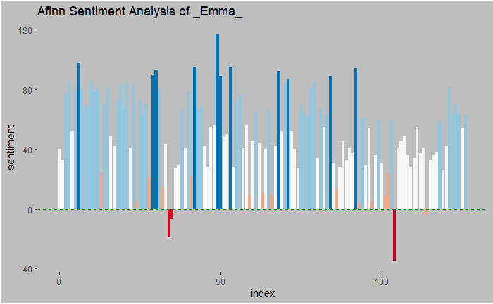

```r
emma_afinn_sentiment %>%
  ggplot(aes(index, sentiment)) +
  geom_col(aes(fill = cut_interval(sentiment, n = 5))) +
  geom_hline(yintercept = 0, color = "forestgreen", linetype = "dashed") +
  scale_fill_brewer(palette = "RdBu", guide = FALSE) +
  theme(panel.background = element_rect(fill = "grey"),
        plot.background = element_rect(fill = "grey"),
        panel.grid.major = element_blank(),
        panel.grid.minor = element_blank()) +
  labs(title = "Afinn Sentiment Analysis of _Emma_")
```

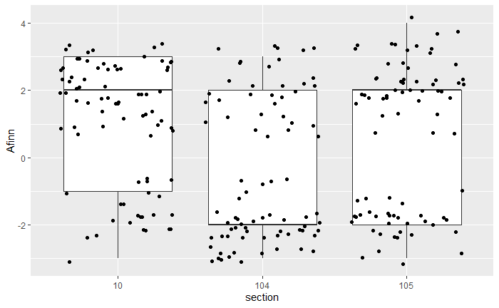

```r
emma_afinn %>%
  mutate(word_count = 1:n(),
         index = as.character(word_count %/% 80)) %>%
  filter(index == 10 | index == 104 | index == 105) %>%
  ggplot(aes(value, index)) +
  geom_boxplot() +
  # geom_boxplot(notch = TRUE) +
  geom_jitter() +
  coord_flip() +
  labs(y = "section", x = "Afinn")
```

## Resources

- [Tidytext package](https://juliasilge.github.io/tidytext/)
- Book: [Text Mining with R](https://www.tidytextmining.com/) by Silge and Robinson
- Data Wrangling with dplyr: ([video](https://juliasilge.github.io/tidytext/) | [workshop](https://rfun.library.duke.edu/portfolio/r_flipped/))
- Data Visualization with ggplot2: ([video](https://warpwire.duke.edu/w/80YEAA/) | [workshop](https://rfun.library.duke.edu/portfolio/ggplot_workshop/))

## License

CC BY-NC Creative Commons: Attribution, Non-commercial https://creativecommons.org/licenses/by-nc/4.0/